# Estadistica

# setup

```r
#install.packages("quantmod")
#install.packages("moments")
#install.packages("nortest")
library(quantmod)
library(moments)
library(nortest)
```

# Carga de datos

```r
df=readxl::read_excel('Libro1.xlsx')
df1=df[which(df$`Época histórica`==1),]
temprano=df1$`Anchura del cráneo` #muestra de datos período temprano
df2=df[which(df$`Época histórica`==2),]
tardio=df2$`Anchura del cráneo` #muestra de datos período tardío
```

# Análisis descriptivo para el período predinástico temprano

## Centralización y dispersión

```r
summary(temprano)
```

```
   Min. 1st Qu.  Median    Mean 3rd Qu.    Max.
  130.0   131.0   131.5   131.5   132.0   134.0
```

```r
sd(temprano)
```

```
[1] 0.8193072
```

```r
var(temprano)
```

```
[1] 0.6712644
```

```r
length(temprano)
```

```
[1] 30
```

La muestra de período temprano tiene una anchura mínima de 130mm y una máxima de 134mm.  
En promedio, la anchura es 131.5mm y a su vez 50% de los valores están situados por encima y 50% por debajo; es decir la mediana es 131.5mm.  
La varianza de la muestra es 0.67, con lo cual la tendencia es a variar por encima y por debajo del promedio en 0.82mm.

## Asimetría y Curtosis

```r
skewness(temprano)
```

```
[1] 0.656983
```

```r
kurtosis(temprano)
```

```
[1] 4.304372
```

La medida de asimetría es 0.65. Teniendo en cuanta que la media es igual a la mediana, podemos decir que la asimetría es baja/moderada y positiva.  
El grado de kurtosis es 4.3, indicando una distribución leptocúrtica, con gran concentración en torno a la media.

## Gráficos

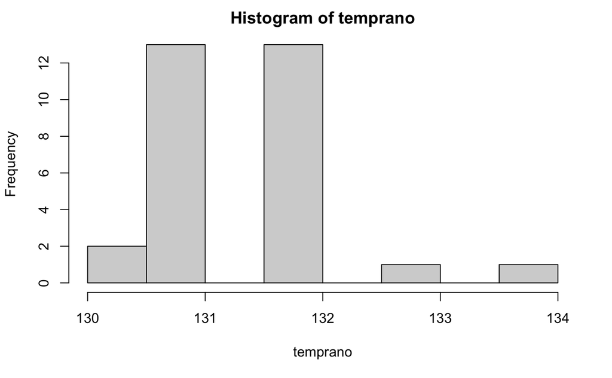

```r
hist(temprano)
```

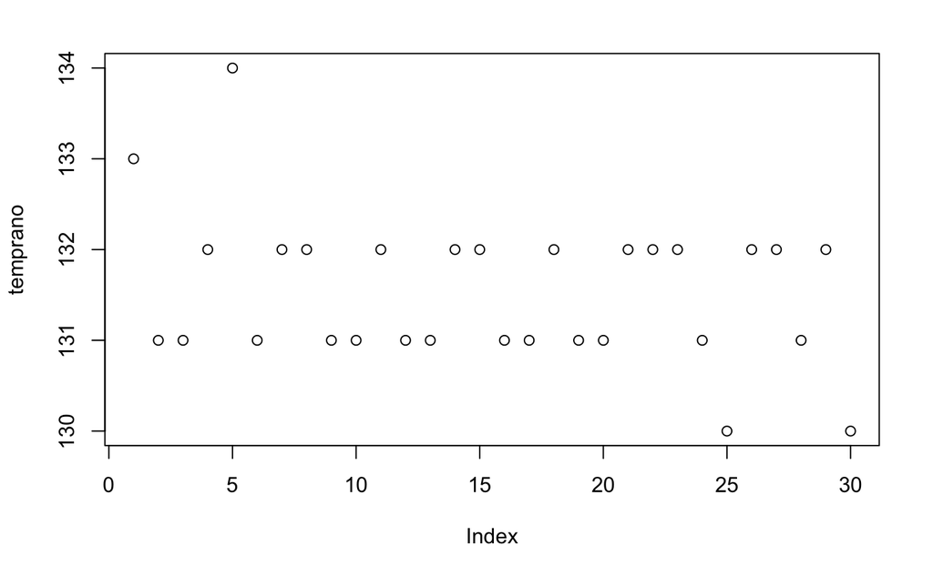

```r
plot(temprano)
```

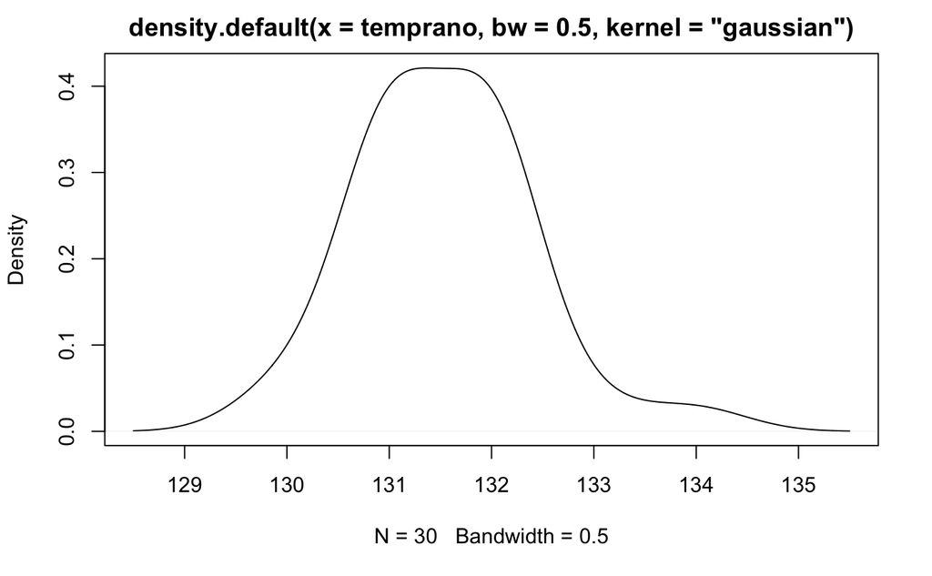

```r
plot(density(temprano,kernel = 'gaussian',bw=0.5))
```

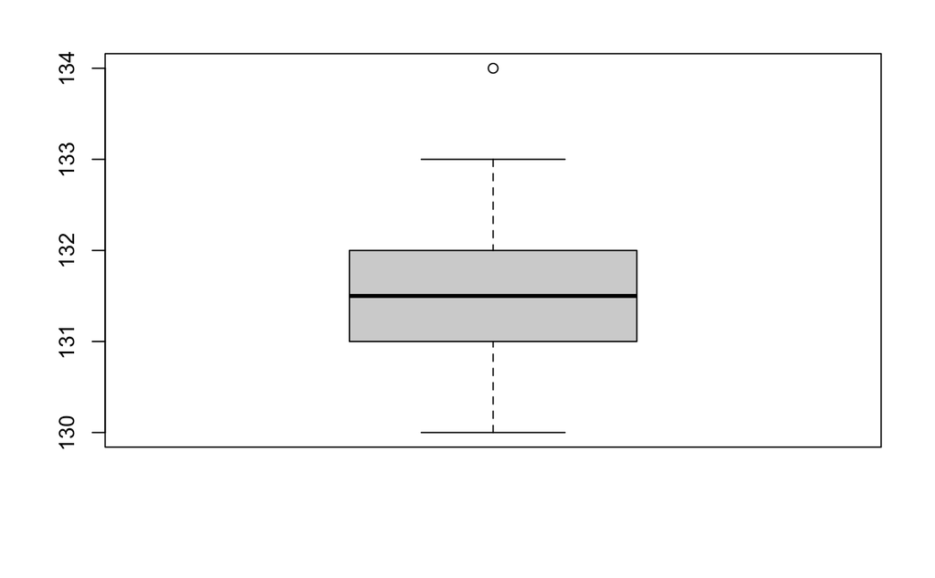

```r
boxplot(temprano)
```

El histograma y la dispersión de puntos nos muestran que la distribución es bimodal.  
El gráfico de densidad muestra que hay gran concentración en torno a la media. Además muestra la cola derecha. El boxplot muestra una distribución bastante centrada salvo por la presencia de un outlier hacia la derecha.

# Análisis descriptivo para el período predinástico tardío

## Centralización y dispersión

```r
summary(tardio)
```

```
   Min. 1st Qu.  Median    Mean 3rd Qu.    Max.
  131.0   132.0   133.0   132.5   133.0   135.0
```

```r
sd(tardio)
```

```
[1] 1.008014
```

```r
var(tardio)
```

```
[1] 1.016092
```

```r
length(tardio)
```

```
[1] 30
```

La muestra de período temprano tiene una anchura mínima de 131mm y una máxima de 135mm.  
En promedio, la anchura es 132.5mm.  
50% de los valores están situados por encima de 133mm y 50% por debajo (mediana).  
La varianza de la muestra es 1.0, con lo cual la tendencia es a variar por encima y por debajo del promedio en 1.0mm.

## Asimetría y Curtosis

```r
skewness(tardio)
```

```
[1] 0.1951055
```

```r
kurtosis(tardio)
```

```
[1] 2.813763
```

La medida de asimetría es 0.19. Teniendo en cuanta que la media es prácticamente igual a la mediana(diferencia menor a 0.5%), podemos decir que la asimetría es muy baja (positiva).  
El grado de kurtosis es 2.8, indicando una distribución moderadamente platicúrtica, con menos concentración en torno a la media. El valor es cercano a tres, por lo tanto es “cercana” a una distribución mesocúrtica.

## Gráficos

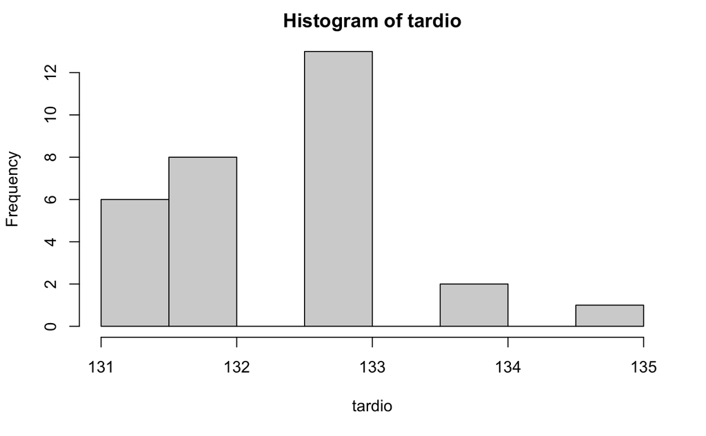

```r
hist(tardio)
```

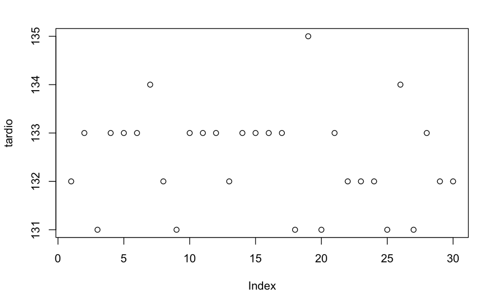

```r
plot(tardio)
```

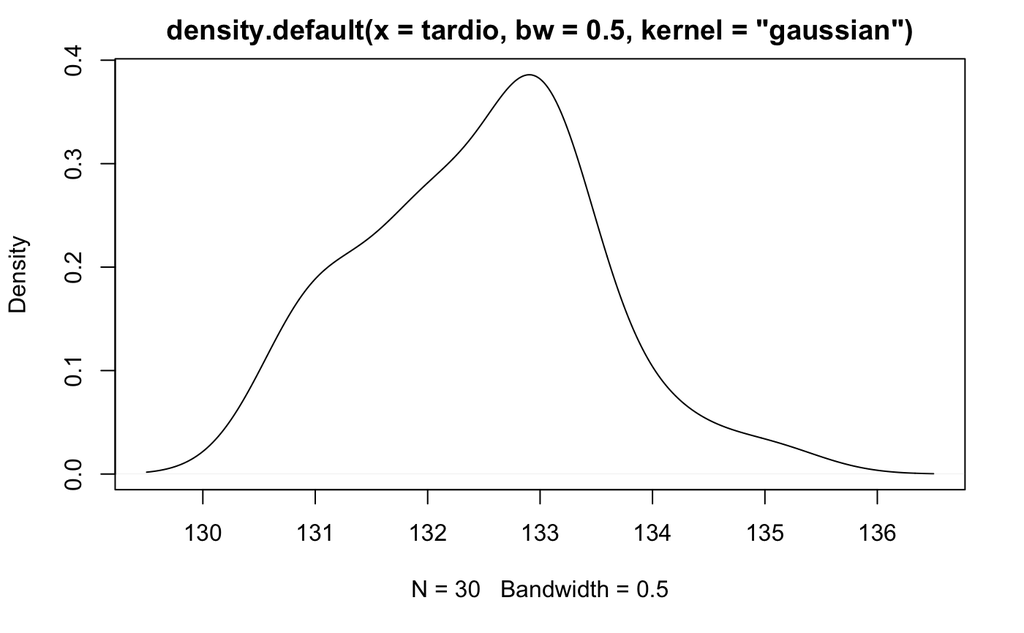

```r
plot(density(tardio,kernel = 'gaussian',bw=0.5))
```

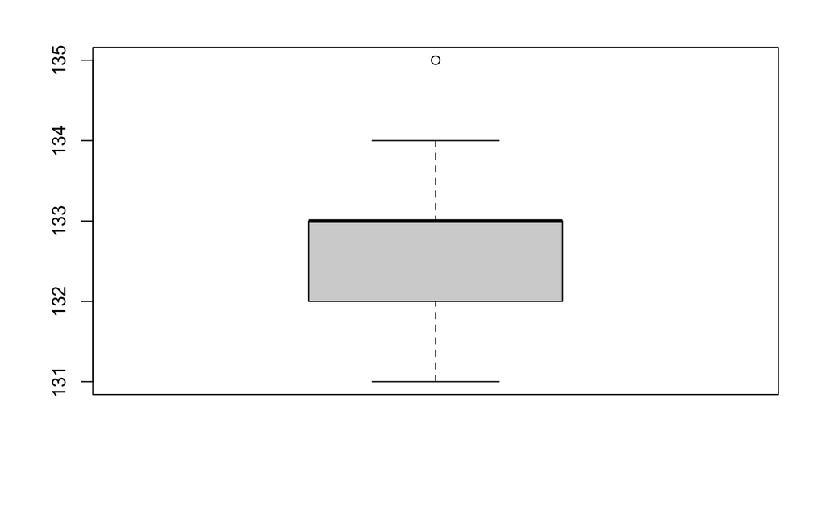

```r
boxplot(tardio)
```

El histograma y la dispersión de puntos nos muestran que la distribución es unimodal.  
El gráfico de densidad muestra que hay menos concentración en torno a la media.  
El boxplot muestra una distribución bastante simétrica, aunque con la mediana hacia la derecha. También se observa un outlier hacia la derecha.

# Test de normalidad

Se realizan las pruebas de normalidad en ambas muestras. Se toma nivel de confianza 0.95.  
La prueba de Kolmogorov-Smirnov asume conocidas la media y la desviación de la población lo cual no es cierto y las tomamos de la muestra. Además n‹50. El test no sería del todo válido.  
Se realiza la prueba anterior con la corrección de Lilliefors.  
Adicionalmente se realiza la prueba de Shapiro-Wilk para realizar una prueba que admita n‹50.

```r
ks.test(temprano,"pnorm",mean(temprano), sd(temprano),alternative = "two.sided")
```

```
    One-sample Kolmogorov-Smirnov test

data:  temprano
D = 0.24246, p-value = 0.05877
alternative hypothesis: two-sided
```

```r
lillie.test(temprano)
```

```
    Lilliefors (Kolmogorov-Smirnov) normality test

data:  temprano
D = 0.24246, p-value = 9.677e-05
```

```r
shapiro.test(temprano)
```

```
    Shapiro-Wilk normality test

data:  temprano
W = 0.83781, p-value = 0.0003481
```

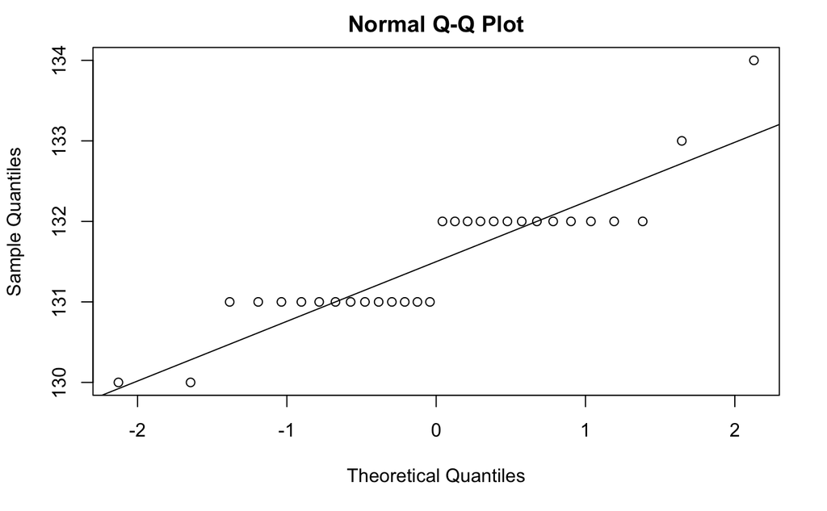

```r
qqnorm(temprano)
qqline(temprano)
```

```r
ks.test(tardio,"pnorm",mean(tardio), sd(tardio), alternative = "two.sided")
```

```
    One-sample Kolmogorov-Smirnov test

data:  tardio
D = 0.23496, p-value = 0.07285
alternative hypothesis: two-sided
```

```r
lillie.test(tardio)
```

```
    Lilliefors (Kolmogorov-Smirnov) normality test

data:  tardio
D = 0.23496, p-value = 0.0001938
```

```r
shapiro.test(tardio)
```

```
    Shapiro-Wilk normality test

data:  tardio
W = 0.8832, p-value = 0.003341
```

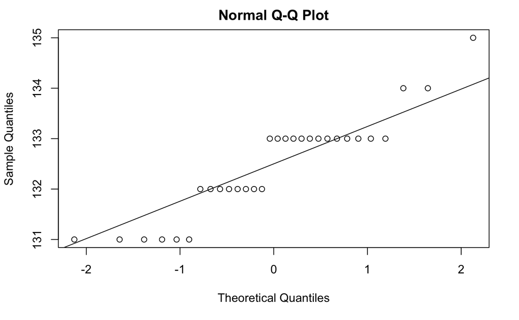

```r
qqnorm(tardio)
qqline(tardio)
```

Resultados(aplica para ambas muestras):  
- K-S sin corrección: se acepta normalidad. (p›0.05)  
- K-S con corrección: se rechaza normalidad. (p‹0.05)  
- S-W: se rechaza normalidad. (p‹0.05)  
- Gráfico: se observa que los puntos están “bastante” cerca de la normal. Resalta el outlier previamente observado en el boxplot.  
- Conclusión: se rechaza normalidad para ambas muestras.

# t-Test dos muestras

## Assumptions

- Se presumen muestras independientes.
- En cuanto a la normalidad de las muestras, la misma fue rechazada en el apartado anterior.
- Se revisa la homogeneidad de las varianzas.

```r
var(temprano)/var(tardio)-1
```

```
[1] -0.3393665
```

La varianza del conjunto *temprano* es 34% menor que la varianza del conjunto *tardio*.  
La homogeneidad de varianzas no se cumple. Por ende se aplica la corrección correspondiente.

## t-Test de dos muestras

```r
t.test(temprano,tardio,var.equal = FALSE,conf.level = 0.9)
```

```
    Welch Two Sample t-test

data:  temprano and tardio
t = -3.9354, df = 55.675, p-value = 0.0002329
alternative hypothesis: true difference in means is not equal to 0
90 percent confidence interval:
 -1.3300289 -0.5366378
sample estimates:
mean of x mean of y
 131.5333  132.4667
```

```r
t.test(temprano,tardio,var.equal = FALSE,conf.level = 0.95)
```

```
    Welch Two Sample t-test

data:  temprano and tardio
t = -3.9354, df = 55.675, p-value = 0.0002329
alternative hypothesis: true difference in means is not equal to 0
95 percent confidence interval:
 -1.4084846 -0.4581821
sample estimates:
mean of x mean of y
 131.5333  132.4667
```

```r
t.test(temprano,tardio,var.equal = FALSE,conf.level = 0.9995)
```

```
    Welch Two Sample t-test

data:  temprano and tardio
t = -3.9354, df = 55.675, p-value = 0.0002329
alternative hypothesis: true difference in means is not equal to 0
99.95 percent confidence interval:
 -1.81013785 -0.05652881
sample estimates:
mean of x mean of y
 131.5333  132.4667
```

Omitiendo el no cumplimiento de normalidad, el test indica que la media de anchura de cráneo en el predinástico temprano es menor que la media de anchura de cráneo en el predinástico tardío, con un 99.95% de confianza.  
Los resultados del test no son concluyentes o válidos ya que no se está cumpliendo la normalidad.

## Reflexiones finales

Si asumimos que la variable *anchura de cráneo* es normal, (como lo es por ejemplo la altura o el peso), podemos decir entonces que la no-normalidad de las muestras es debida a su poca cantidad (muestra muy chica) o a que no son representativas. Esto último se daría si por ejemplo se estuvieran midiendo cráneos de una etnia o una familia específica, cuya constitución fuera similar entre ellos, o incluso diferente de la media poblacional. Considerando que todos los cráneos se encuentran en el mismo yacimiento, esto parece una hipótesis razonable.  
Para profundizar el análisis se sugiere, si fuera posible, por un lado recolectar más muestras, y por otro lado tomar muestras de otros yacimientos arqueológicos.